# Kristen Boysen (username:knboysen) Site

Kristen Boysen

January 15, 2016

[output not shown]

## Content

I am interested on climate impacts on a large landscape scale, how ecosystems and species will adapt, and how we as managers can help improve the resilience of these environments.

## Techniques

There are several techniques I am looking forward to learning:

1. Dealing with large datasets
2. Using Git to collaborate with other researchers
3. Visualizing and sharing data analytics

## Data

I did make up some data today during class:

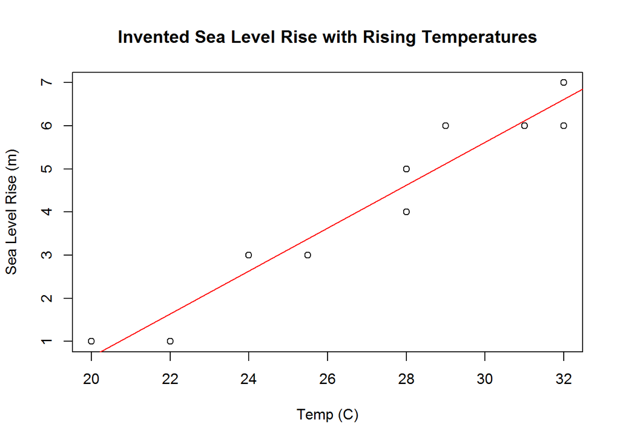

I do think United National Environmental Programme will have some interesting data, as will NOAA.

## Penguins

Here is a photo of a molting, juvenile Gentoo penguin (*Pygoscelis papua*) on [King George Island](https://www.google.com/maps/place/King+George+Island,+Antarctica/@-62.0757944,-58.8658154,9z/data=!3m1!4b1!4m2!3m1!1s0xbc738f0fdffd7975:0x759c74bafe566d71), Antarctica. I took this photo in February, 2011 while working for NOAA.

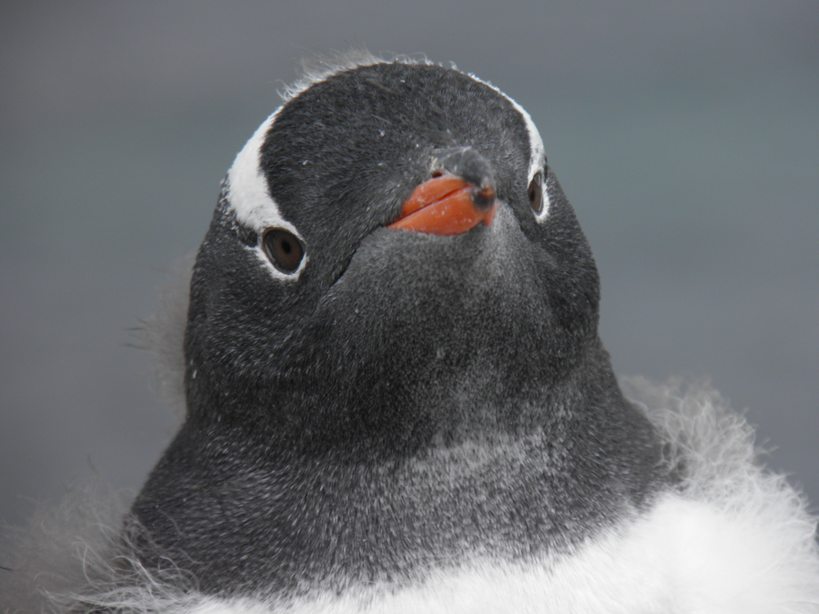

## Sea Level Rise Data from UNEP

I downloaded data from the United National Environmental Programme’s [Environmental Data Explorer](http://ede.grid.unep.ch/) that contains the percent of total land area that is below 5m elevation for each country. Below are summary statistics of that data:

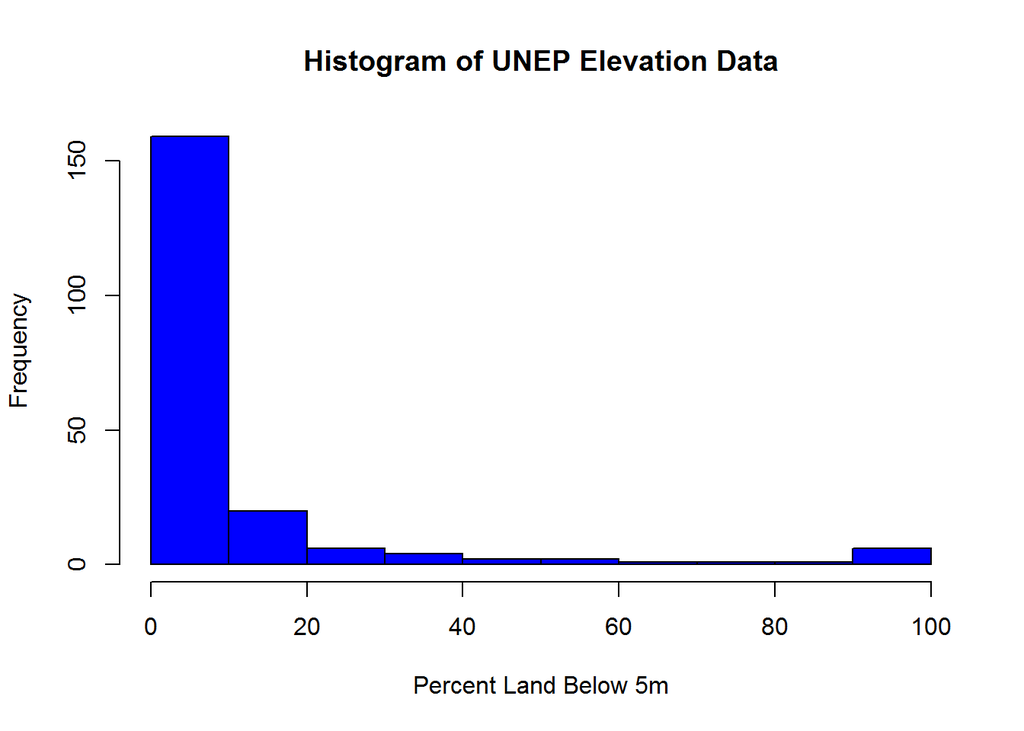

```r
# read csv
sea_level_unep_kb <- read.csv("data/knboysen_sea_level_unep.csv")

# output histogram
hist(sea_level_unep_kb$Percent_land_under_5m, xlab="Percent Land Below 5m", main="Histogram of UNEP Elevation Data", col ="blue")
```

This data set includes 237 countries. Below is a table of the countries that are completely (100% of land area) below 5m of elevation

```r
subset<- subset(sea_level_unep_kb, Percent_land_under_5m==100)
print(subset[,c(1,3,15)])
```

```
##     Country.Name     GEO.Region Percent_land_under_5m
## 199     Maldives Asia + Pacific                   100
## 200       Monaco         Europe                   100
## 201  South Sudan         Africa                   100
## 202       Tuvalu Asia + Pacific                   100
```

The mean percent of land under 5m is 9.7063412%.

## Data Wrangling

Install Packages

```r
# Run this chunk only once in your Console
# Do not evaluate when knitting Rmarkdown

# list of packages
pkgs = c(
  'readr',        # read csv
  'readxl',       # read xls
  'dplyr',        # data frame manipulation
  'tidyr',        # data tidying
  'nycflights13', # test dataset of NYC flights for 2013
  'gapminder')    # test dataset of life expectancy and popultion

# install packages if not found
for (p in pkgs){
  if (!require(p, character.only=T)){
    install.packages(p)
  }
}
```

## utils::read.csv

Traditionally, you would read a CSV like so:

```r
d = read.csv('../data/r-ecology/species.csv')
d
```

```
##    species_id            genus         species    taxa
## 1          AB       Amphispiza       bilineata    Bird
## 2          AH Ammospermophilus         harrisi  Rodent
## 3          AS       Ammodramus      savannarum    Bird
## 4          BA          Baiomys         taylori  Rodent
## 5          CB  Campylorhynchus brunneicapillus    Bird
## 6          CM      Calamospiza     melanocorys    Bird
## 7          CQ       Callipepla        squamata    Bird
## 8          CS         Crotalus      scutalatus Reptile
## 9          CT    Cnemidophorus          tigris Reptile
## 10         CU    Cnemidophorus       uniparens Reptile
## 11         CV         Crotalus         viridis Reptile
## 12         DM        Dipodomys        merriami  Rodent
## 13         DO        Dipodomys           ordii  Rodent
## 14         DS        Dipodomys     spectabilis  Rodent
```

[output cut: 40 more lines]

```r
head(d) ##species_ID is a factor
```

```
##   species_id            genus         species   taxa
## 1         AB       Amphispiza       bilineata   Bird
## 2         AH Ammospermophilus         harrisi Rodent
## 3         AS       Ammodramus      savannarum   Bird
## 4         BA          Baiomys         taylori Rodent
## 5         CB  Campylorhynchus brunneicapillus   Bird
## 6         CM      Calamospiza     melanocorys   Bird
```

```r
summary(d)
```

```
##    species_id             genus         species        taxa
##  AB     : 1   Chaetodipus    : 4   sp.      :10   Bird   :13
##  AH     : 1   Dipodomys      : 4   hispidus : 2   Rabbit : 1
##  AS     : 1   Reithrodontomys: 4   albigula : 1   Reptile: 9
##  BA     : 1   Sigmodon       : 4   audubonii: 1   Rodent :31
##  CB     : 1   Onychomys      : 3   baileyi  : 1
##  CM     : 1   Peromyscus     : 3   bilineata: 1
##  (Other):48   (Other)        :32   (Other)  :38
```

readr::read_csv Better yet, try read_csv:

```r
library(readr)

d = read_csv('../data/r-ecology/species.csv')
d
```

```
##    species_id            genus         species    taxa
## 1          AB       Amphispiza       bilineata    Bird
## 2          AH Ammospermophilus         harrisi  Rodent
## 3          AS       Ammodramus      savannarum    Bird
## 4          BA          Baiomys         taylori  Rodent
## 5          CB  Campylorhynchus brunneicapillus    Bird
## 6          CM      Calamospiza     melanocorys    Bird
## 7          CQ       Callipepla        squamata    Bird
## 8          CS         Crotalus      scutalatus Reptile
## 9          CT    Cnemidophorus          tigris Reptile
## 10         CU    Cnemidophorus       uniparens Reptile
## 11         CV         Crotalus         viridis Reptile
## 12         DM        Dipodomys        merriami  Rodent
## 13         DO        Dipodomys           ordii  Rodent
## 14         DS        Dipodomys     spectabilis  Rodent
```

[output cut: 40 more lines]

```r
head(d) ##now the specices_ID is a "character". why does this matter, BB?!
```

```
##   species_id            genus         species   taxa
## 1         AB       Amphispiza       bilineata   Bird
## 2         AH Ammospermophilus         harrisi Rodent
## 3         AS       Ammodramus      savannarum   Bird
## 4         BA          Baiomys         taylori Rodent
## 5         CB  Campylorhynchus brunneicapillus   Bird
## 6         CM      Calamospiza     melanocorys   Bird
```

```r
summary(d)
```

```
##   species_id           genus             species
##  Length:54          Length:54          Length:54
##  Class :character   Class :character   Class :character
##  Mode  :character   Mode  :character   Mode  :character
##      taxa
##  Length:54
##  Class :character
##  Mode  :character
```

dplry::tbl_df Now convert to a dplyr table:

```r
library(readr)
library(dplyr)
d = read_csv('../data/r-ecology/species.csv') %>%
  tbl_df()
d
```

```
## Source: local data frame [54 x 4]
##
##    species_id            genus         species    taxa
##         (chr)            (chr)           (chr)   (chr)
## 1          AB       Amphispiza       bilineata    Bird
## 2          AH Ammospermophilus         harrisi  Rodent
## 3          AS       Ammodramus      savannarum    Bird
## 4          BA          Baiomys         taylori  Rodent
## 5          CB  Campylorhynchus brunneicapillus    Bird
## 6          CM      Calamospiza     melanocorys    Bird
## 7          CQ       Callipepla        squamata    Bird
## 8          CS         Crotalus      scutalatus Reptile
## 9          CT    Cnemidophorus          tigris Reptile
## 10         CU    Cnemidophorus       uniparens Reptile
## ..        ...              ...             ...     ...
```

```r
head(d)
```

```
## Source: local data frame [6 x 4]
##
##   species_id            genus         species   taxa
##        (chr)            (chr)           (chr)  (chr)
## 1         AB       Amphispiza       bilineata   Bird
## 2         AH Ammospermophilus         harrisi Rodent
## 3         AS       Ammodramus      savannarum   Bird
## 4         BA          Baiomys         taylori Rodent
## 5         CB  Campylorhynchus brunneicapillus   Bird
## 6         CM      Calamospiza     melanocorys   Bird
```

```r
summary(d)
```

```
##   species_id           genus             species
##  Length:54          Length:54          Length:54
##  Class :character   Class :character   Class :character
##  Mode  :character   Mode  :character   Mode  :character
##      taxa
##  Length:54
##  Class :character
##  Mode  :character
```

```r
glimpse(d)
```

```
## Observations: 54
## Variables: 4
## $ species_id (chr) "AB", "AH", "AS", "BA", "CB", "CM", "CQ", "CS", "CT...
## $ genus      (chr) "Amphispiza", "Ammospermophilus", "Ammodramus", "Ba...
## $ species    (chr) "bilineata", "harrisi", "savannarum", "taylori", "b...
## $ taxa       (chr) "Bird", "Rodent", "Bird", "Rodent", "Bird", "Bird",...
```

```r
b=read_csv('C:/Users/Kristen/Documents/BREN/winter16/env_info/env-info/data/r-ecology/surveys.csv') %>%
  select(species_id, year) %>%
  filter(species_id== "AB") %>%
  group_by(species_id, year) %>%
  summarize(count = n())
```

### elegance with dplry

week 3 individual assignment

```r
library(readr)
library(dplyr)
#read is csv
surveys = read_csv('../data/r-ecology/surveys.csv')

surveys %T>% ##tee operator is good for printing or plotting that wouldn't ouput a return usually
  glimpse() %>%
  select(species_id, year) %>% #selected columns
  filter(species_id == 'NL') %>% ##with specific row entries
  group_by(year) %>%
  summarize(n=n()) %T>%  ##summarize n counts
  glimpse() %>% ##view the table before writing it. it seems to work. 31 "NL" counts in 1977
  write_csv('data/surveys_kboysen.csv') ##hooray it works!
```

```
## Observations: 35,549
## Variables: 9
## $ record_id       (int) 1, 2, 3, 4, 5, 6, 7, 8, 9, 10, 11, 12, 13, 14,...
## $ month           (int) 7, 7, 7, 7, 7, 7, 7, 7, 7, 7, 7, 7, 7, 7, 7, 7...
## $ day             (int) 16, 16, 16, 16, 16, 16, 16, 16, 16, 16, 16, 16...
## $ year            (int) 1977, 1977, 1977, 1977, 1977, 1977, 1977, 1977...
## $ plot_id         (int) 2, 3, 2, 7, 3, 1, 2, 1, 1, 6, 5, 7, 3, 8, 6, 4...
## $ species_id      (chr) "NL", "NL", "DM", "DM", "DM", "PF", "PE", "DM"...
## $ sex             (chr) "M", "M", "F", "M", "M", "M", "F", "M", "F", "...
## $ hindfoot_length (int) 32, 33, 37, 36, 35, 14, NA, 37, 34, 20, 53, 38...
## $ weight          (int) NA, NA, NA, NA, NA, NA, NA, NA, NA, NA, NA, NA...
## Observations: 26
## Variables: 2
## $ year (int) 1977, 1978, 1979, 1980, 1981, 1982, 1983, 1984, 1985, 198...
## $ n    (int) 31, 48, 30, 57, 63, 111, 98, 64, 45, 60, 128, 102, 67, 29...
```

### Wrangling Webinar

#### Piping

[output not shown]

```r
library(tidyr)
library(dplyr)

select(tb, child:elderly) ##verses
```

```
## Source: local data frame [3,800 x 3]
##
##    child adult elderly
##    (int) (int)   (int)
## 1     NA    NA      NA
## 2     NA    NA      NA
## 3     NA    NA      NA
## 4     NA    NA      NA
## 5      5    96       1
## 6      0    26       0
## 7     45  1142      20
## 8     30   500      41
## 9     25   484       8
## 10     8   212       8
## ..   ...   ...     ...
```

```r
tb %>% select(child:elderly)
```

```
## Source: local data frame [3,800 x 3]
##
##    child adult elderly
##    (int) (int)   (int)
## 1     NA    NA      NA
## 2     NA    NA      NA
## 3     NA    NA      NA
## 4     NA    NA      NA
## 5      5    96       1
## 6      0    26       0
## 7     45  1142      20
## 8     30   500      41
## 9     25   484       8
## 10     8   212       8
## ..   ...   ...     ...
```

```r
#yay piping
```

### tidyr

```r
library(tidyr)
##cases, a dataset about TB

gather(cases, "year", "n", 2:4) ##cases is the dataframe we are reshaping, "year"/"n" are the new column names, and we are collapsing columns 2-4
```

```
##   country year     n
## 1      FR 2011  7000
## 2      DE 2011  5800
## 3      US 2011 15000
## 4      FR 2012  6900
## 5      DE 2012  6000
## 6      US 2012 14000
## 7      FR 2013  7000
## 8      DE 2013  6200
## 9      US 2013 13000
```

```r
##the opposite function is "spread"
#use "pollution" dataset

spread(pollution, size, amount)
```

```
##       city large small
## 1  Beijing   121    56
## 2   London    22    16
## 3 New York    23    14
```

```r
#creates a new columns for each size (large & small), and populates it with the "amount"


##separate!
storms2<- separate(storms, date, c("year", "month", "day"), sep = "-") ##separates the date of the storm by the year month day (dash separates the original date) this is very cool

##unite!
unite(storms2, "date", year, month, day, sep = "-") ## put it back together again
```

```
## Source: local data frame [6 x 4]
##
##     storm  wind pressure       date
##     (chr) (int)    (int)      (chr)
## 1 Alberto   110     1007 2000-08-03
## 2    Alex    45     1009 1998-07-27
## 3 Allison    65     1005 1995-06-03
## 4     Ana    40     1013 1997-06-30
## 5  Arlene    50     1010 1999-06-11
## 6  Arthur    45     1010 1996-06-17
```